# Inegalité d’accès aux bornes de recharge dans la banlieu proche

Sihem CHIBANI, Jarod LUMUENI, Sabrina PLAYEZ

2025-05-07

## Introduction : Inégalité d’accès aux bornes de recharge dans la banlieue proche

La transition écologique est aujourd’hui un enjeu crucial face à l’urgence climatique. Parmi les transformations en cours, le développement des véhicules électriques s’impose comme une solution plus durable, censée remplacer progressivement les véhicules thermiques. Pour accompagner cette évolution, les territoires doivent mettre en place des infrastructures adaptées, notamment un réseau de bornes de recharge suffisant, accessible et bien réparti.

Mais dans les faits, l’accès à ces bornes n’est pas le même partout. À travers l’exemple de trois communes situées en banlieue proche de Paris : Nanterre, Choisy-le-Roi et Drancy, ce dossier propose d’interroger les inégalités territoriales qui accompagnent la transition écologique. Dans quelle mesure l’inégale répartition des infrastructures de recharge influence-t-elle la capacité des différents territoires à s’engager dans la transition vers la mobilité électrique ?

## Présentation des villes étudiées

Nanterre Située dans les Hauts-de-Seine (92), à l’ouest de Paris, Nanterre est une commune dense et urbanisée de la proche banlieue. Elle fait partie de la métropole du Grand Paris et accueille le quartier d’affaires de La Défense.

Code postal : 92000 Code INSEE : 92050 Population : environ 97 000 habitants Superficie : 12,2 km²

Drancy Commune de Seine-Saint-Denis (93), Drancy se situe au nord-est de Paris. Elle est marquée par un fort tissu résidentiel et une histoire ouvrière.

Code postal : 93700 Code INSEE : 93029 Population : environ 72 000 habitants Superficie : 7,8 km²

Choisy-le-Roi Située dans le Val-de-Marne (94), Choisy-le-Roi est une commune de la banlieue sud, en bord de Seine. Elle possède un passé industriel et un urbanisme en transformation.

Code postal : 94600 Code INSEE : 94022 Population : environ 46 000 habitants Superficie : 5,5 km²

## Carte des trois villes

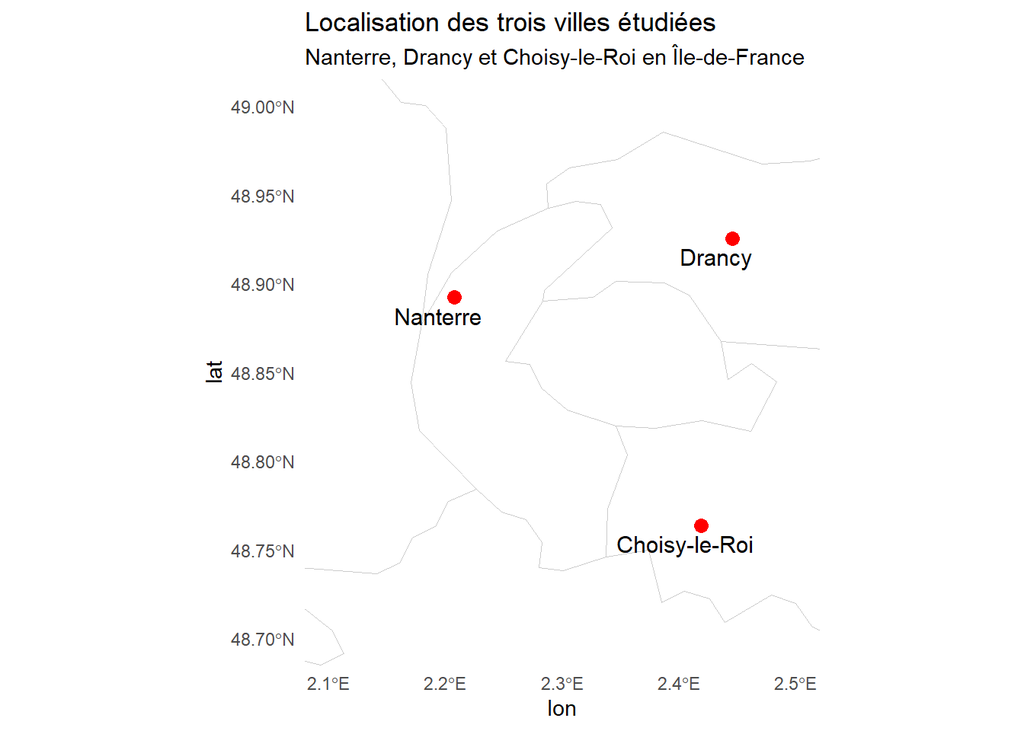

## Analyse des bornes de recharge à Nanterre

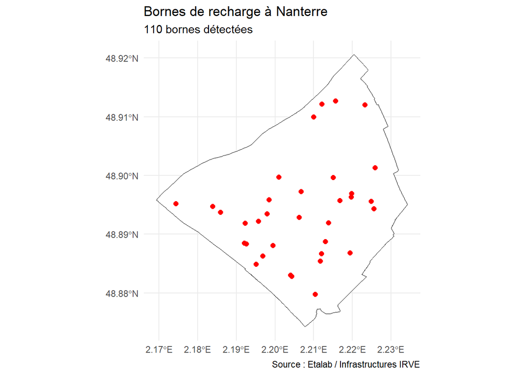

[output not shown]

## Analyse des bornes de recharge à Nanterre

La ville de Nanterre, située dans les Hauts-de-Seine, compte 110 bornes de recharge pour véhicules électriques réparties sur une superficie de 12,2 km². Cela représente une densité d’environ 9,02 bornes par km². Chaque borne dessert en moyenne 882 habitants.

Malgré sa proximité avec Paris et son appartenance à la métropole du Grand Paris, Nanterre présente une densité modérée d’infrastructures de recharge. Cette situation peut limiter l’adoption des véhicules électriques pour une partie des habitants, notamment ceux qui ne disposent pas d’un accès privé à une borne. Cela illustre une certaine inégalité territoriale dans l’accès aux infrastructures écologiques, même dans des zones urbaines relativement centrales.

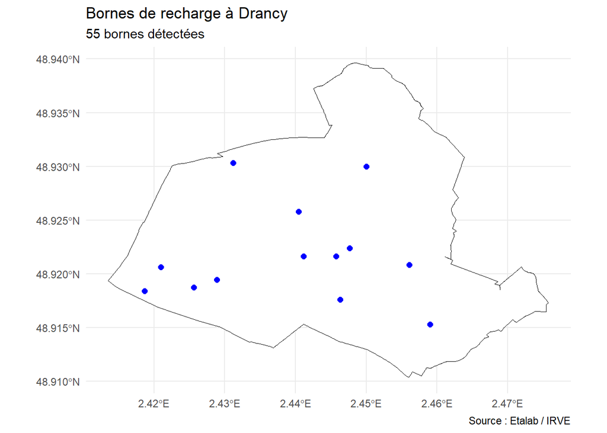

[output not shown]

## Analyse des bornes de recharge à Drancy

La commune de Drancy, située en Seine-Saint-Denis, dispose de 55 bornes de recharge pour véhicules électriques, réparties sur une superficie de 7,8 km². Cela représente une densité d’environ 7,05 bornes par km². Chaque borne dessert en moyenne 1 297 habitants.

Comparée à d’autres communes de la proche banlieue parisienne, Drancy affiche une densité d’équipements légèrement inférieure. Cette situation peut refléter un retard en matière de déploiement des infrastructures de recharge, dans un territoire pourtant fortement urbanisé. Cela soulève la question d’une inégalité d’accès à la transition écologique selon les communes, leurs moyens, et leurs priorités politiques.

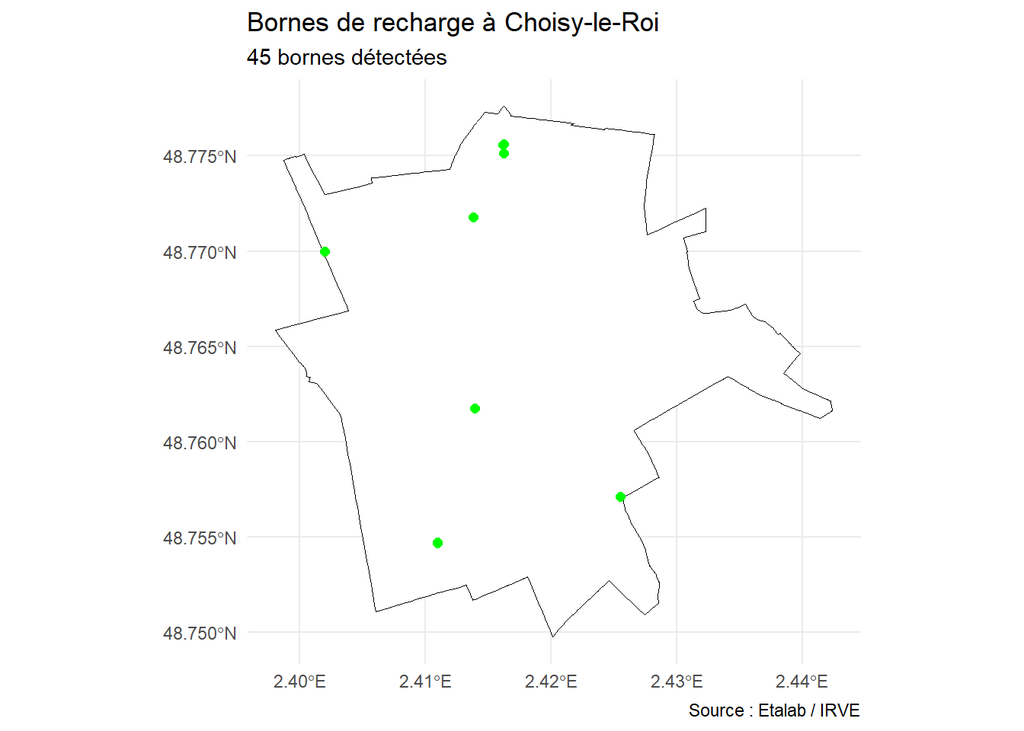

[output not shown]

## Analyse des bornes de recharge à Choisy-le-Roi

Choisy-le-Roi, située dans le Val-de-Marne au sud-est de Paris, compte 45 bornes de recharge pour véhicules électriques réparties sur une superficie de 5,5 km². Cela représente une densité d’environ 8,18 bornes par km². Chaque borne couvre en moyenne 1 022 habitants.

Malgré sa taille plus réduite, Choisy-le-Roi affiche une densité de bornes relativement comparable à celle de Nanterre, ce qui témoigne d’un effort municipal pour équiper le territoire. Toutefois, le ratio habitants par borne reste élevé, ce qui pourrait limiter l’accessibilité à ces infrastructures si l’usage des véhicules électriques se généralise. Cela souligne l’importance d’adapter le maillage des bornes à la densité de population, pour garantir une transition écologique plus équitable.

## Tableau comparatif des 3 villes

Tableau comparatif des infrastructures de recharge dans les trois villes

| Ville | Nombre.de.bornes | Superficie..km.. | Bornes.km. | Population | Habitants.par.borne |
| --- | --- | --- | --- | --- | --- |
| Nanterre | 110 | 12.2 | 9.02 | 97000 | 882 |
| Drancy | 55 | 7.8 | 7.05 | 71363 | 1297 |
| Choisy-le-Roi | 45 | 5.5 | 8.18 | 46000 | 1022 |

## Analyse comparative : des inégalités d’accès visibles entre trois villes de banlieue proche

L’étude comparative des villes de Nanterre, Drancy et Choisy-le-Roi révèle des inégalités claires dans la répartition des bornes de recharge pour véhicules électriques en banlieue parisienne. Ces disparités, à la fois quantitatives et qualitatives, illustrent à quel point la transition écologique n’avance pas au même rythme selon les territoires.

D’un point de vue quantitatif, Nanterre se distingue comme la ville la mieux équipée : avec 110 bornes pour 97 000 habitants, réparties sur 12,2 km², elle atteint une densité de 9,02 bornes/km² et un ratio de 882 habitants par borne. Cette situation reflète une politique d’aménagement plutôt favorable à la mobilité électrique, probablement soutenue par la proximité de La Défense et les ressources plus importantes des Hauts-de-Seine.

À l’opposé, Drancy, commune populaire de Seine-Saint-Denis, affiche un niveau d’équipement nettement plus faible : 55 bornes pour 71 363 habitants, soit 7,05 bornes/km² et surtout 1 297 habitants par borne. Ces chiffres traduisent un accès plus difficile à l’infrastructure, dans un département déjà marqué par des fragilités sociales et économiques. La faible densité de bornes risque d’aggraver les inégalités d’accès à la mobilité durable pour les habitants de cette ville.

Choisy-le-Roi, quant à elle, présente un profil intermédiaire : 45 bornes pour 46 000 habitants, avec 8,18 bornes/km² et 1 022 habitants par borne. Bien qu’elle dispose de moins de bornes que Nanterre, sa densité reste satisfaisante au regard de sa taille. Cela suggère un certain équilibre dans l’aménagement, mais encore insuffisant pour répondre aux besoins croissants liés à l’essor du véhicule électrique.

Ce contraste entre les trois communes montre que l’équipement en bornes de recharge ne dépend pas uniquement de la superficie ou de la population, mais aussi du volontarisme politique, des ressources financières disponibles et des dynamiques urbaines locales.

## Comparative avec Paris

Si l’on compare ces chiffres à ceux de la ville de Paris, les écarts deviennent encore plus fort. À la fin de 2023, Paris comptait environ 4 000 bornes de recharge publiques, pour une superficie de 105 km² et une population d’environ 2,1 millions d’habitants. Cela représente une densité d’environ 38 bornes/km², soit 1 borne pour environ 525 habitants un niveau d’équipement nettement supérieur à celui observé en banlieue.

Ce contraste illustre une forme de fracture territoriale : alors que Paris concentre les investissements et bénéficie d’une politique ambitieuse en matière de mobilité électrique (zones à faibles émissions, restrictions sur les véhicules thermiques, etc.), les communes de la banlieue proche doivent souvent composer avec des moyens moindres, des priorités politiques différentes, et une urbanisation moins dense ou moins planifiée pour accueillir ces infrastructures.

## Conclusion

Ce travail a permis de mettre en évidence les disparités territoriales dans l’accès aux bornes de recharge pour véhicules électriques à travers l’étude de trois communes de la banlieue parisienne : Nanterre, Drancy et Choisy-le-Roi. Bien que toutes trois soient situées dans la proche périphérie de Paris, elles présentent des situations très contrastées, tant en termes de nombre de bornes disponibles que de densité par habitant ou par superficie.

Il apparaît clairement que la transition écologique, et plus précisément la mobilité électrique, ne progresse pas de manière uniforme sur le territoire. Les communes les mieux dotées, comme Nanterre, bénéficient d’un cadre favorable et de moyens adaptés. À l’inverse, des villes comme Drancy rencontrent encore de réelles difficultés à offrir un accès équitable à ces infrastructures pourtant essentielles pour accompagner les transformations environnementales.

Cette inégalité d’équipement pose un véritable enjeu d’équité sociale et territoriale : comment encourager tous les citoyens à adopter des comportements plus durables si les moyens d’y parvenir ne sont pas accessibles partout ? À cela s’ajoute le risque de renforcer les écarts déjà existants entre les territoires les plus favorisés et ceux qui peinent à suivre les ambitions nationales de neutralité carbone.

Ainsi, cette étude locale illustre un défi beaucoup plus large : celui d’une transition écologique juste, qui n’oublie aucun territoire, aucune population, et qui repose sur une véritable coordination entre les politiques nationales, régionales et municipales. Car la réussite de cette transition ne dépend pas seulement des innovations technologiques, mais aussi de la capacité collective à en garantir l’accès équitable à tous.